# Introduction to Statistical Tests - Exercise Solutions

BICF@UTSouthwestern.edu

November 28, 2016

### Normal Distribution & Normality Test

**1. Run the following code to generate a sample of size 50 from the Student t distribution with degree of freedom 30, and then:**

- **generate a histogram of sample x;**
- **calculate its summary statistics (min, Q1, median, mean, Q3, max);**
- **generate a Q-Q plot with 95% CI for sample x;**
- **run Shapiro-Wilk normality test on sample x.**

```r
set.seed(57)
x <- rt(n=50,df=30)
```

**Solution:**

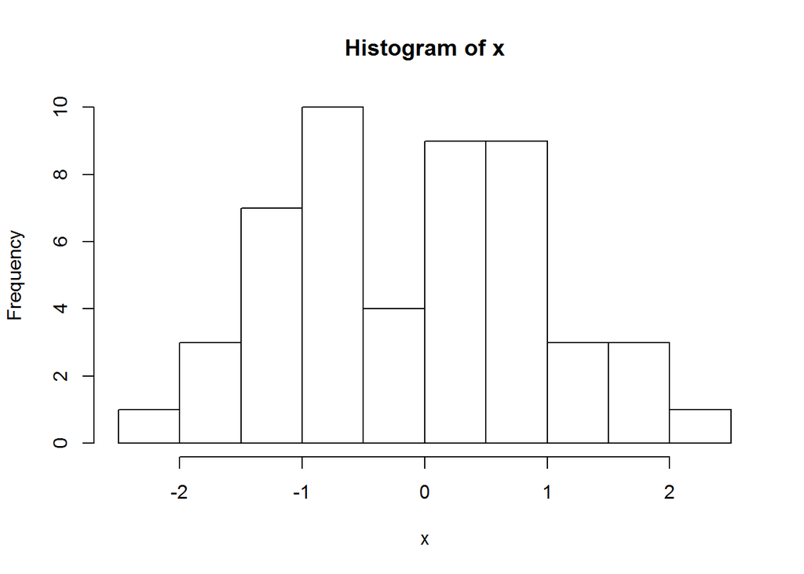

```r
hist(x, breaks=15)
```

```r
summary(x)
```

```
##     Min.  1st Qu.   Median     Mean  3rd Qu.     Max.
## -2.14200 -0.91750  0.03698 -0.06852  0.60500  2.11500
```

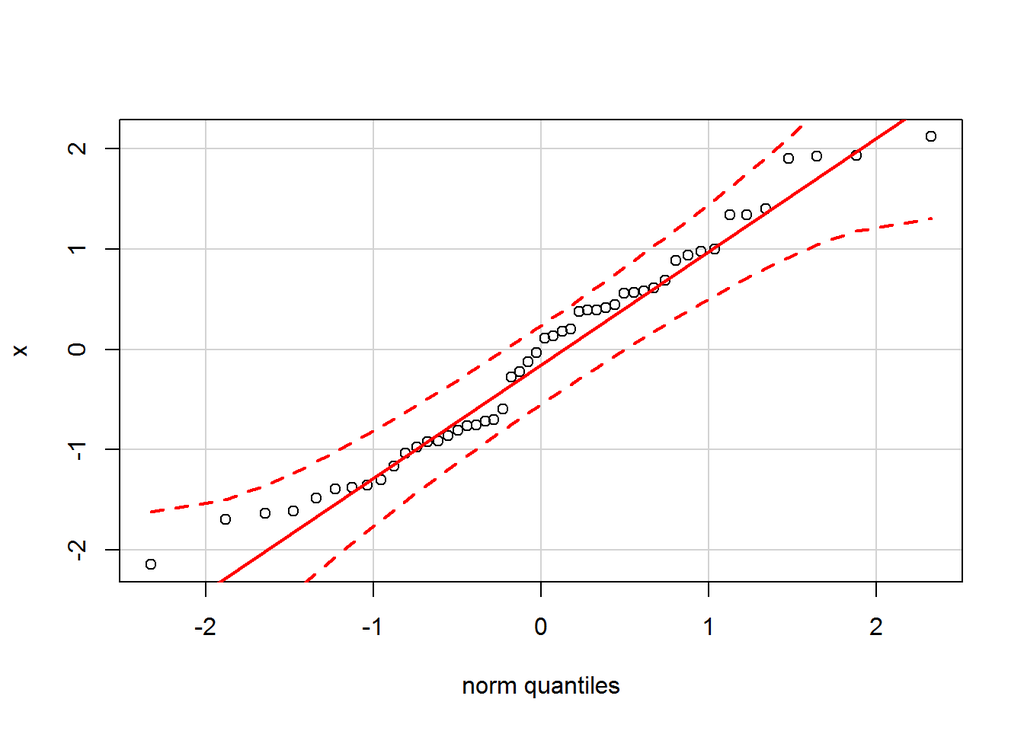

```r
car::qqPlot(x)
```

```r
shapiro.test(x)
```

```
##
##  Shapiro-Wilk normality test
##
## data:  x
## W = 0.96843, p-value = 0.1996
```

**2. Run normality test on diastolic blood pressure (DIABP) in DIG data for female patients only.**

**Solution:**

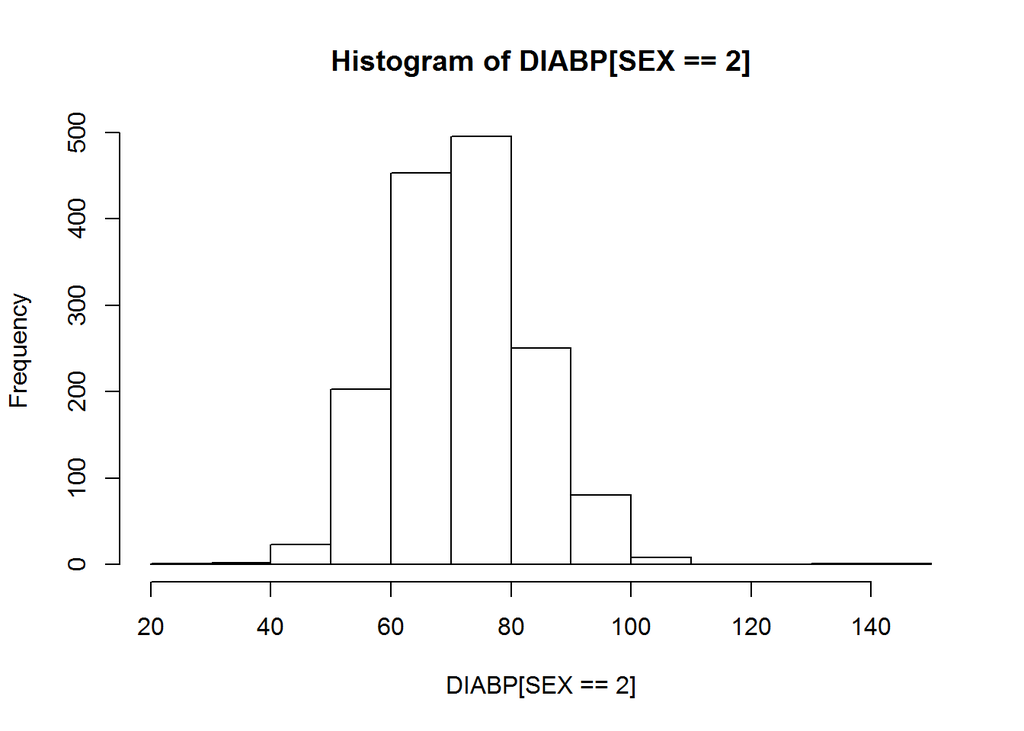

```r
hist(DIABP[SEX==2], breaks=15)
```

```r
summary(DIABP[SEX==2])
```

```
##    Min. 1st Qu.  Median    Mean 3rd Qu.    Max.    NA's
##   25.00   70.00   75.00   74.95   80.00  150.00       2
```

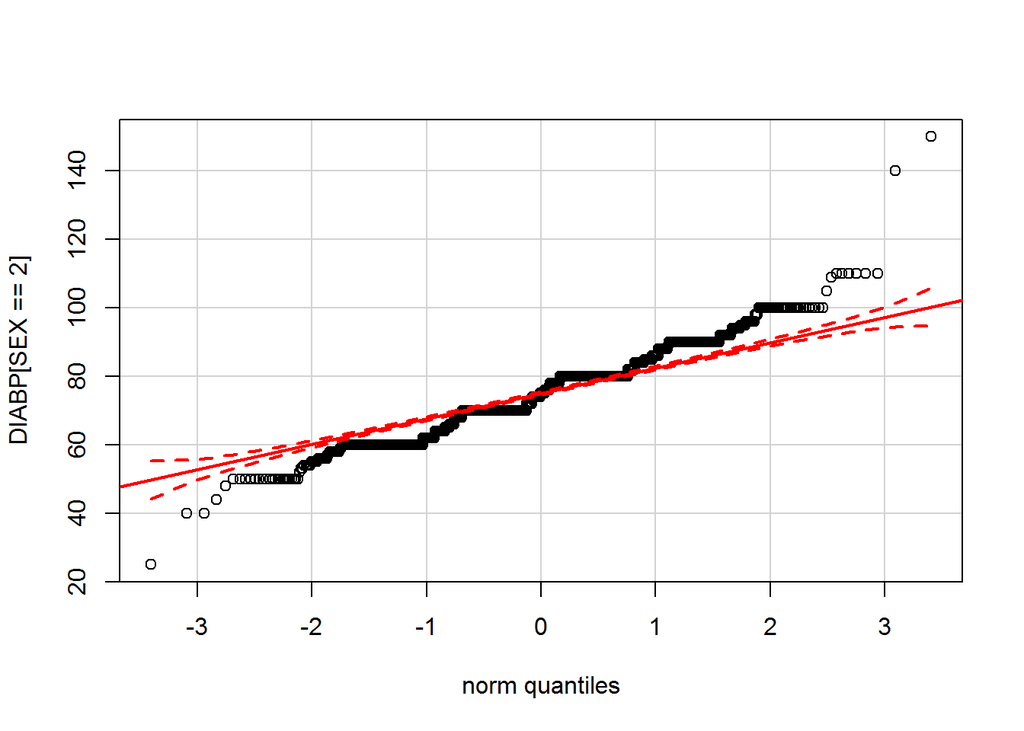

```r
car::qqPlot(DIABP[SEX==2])
```

```r
shapiro.test(DIABP[SEX==2])
```

```
##
##  Shapiro-Wilk normality test
##
## data:  DIABP[SEX == 2]
## W = 0.96502, p-value < 2.2e-16
```

### Two-sample T-test & Wilcoxon Rank Sum Test

**3. Choose an appropriate test to compare the diastolic blood pressure of the two gender groups in DIG data.**

**Solution:**

```r
wilcox.test(DIABP~SEX)
```

```
##
##  Wilcoxon rank sum test with continuity correction
##
## data:  DIABP by SEX
## W = 3996700, p-value = 0.9208
## alternative hypothesis: true location shift is not equal to 0
```

```r
summary(DIABP[SEX==1])
```

```
##    Min. 1st Qu.  Median    Mean 3rd Qu.    Max.    NA's
##   38.00   70.00   75.00   74.89   80.00  184.00       3
```

```r
summary(DIABP[SEX==2])
```

```
##    Min. 1st Qu.  Median    Mean 3rd Qu.    Max.    NA's
##   25.00   70.00   75.00   74.95   80.00  150.00       2
```

**4. Run the following simulation code first and then choose an appropriate test to compare the mean of sample x1 and x2.**

```r
set.seed(57)
x1 <- rnorm(100, 2.2, 1)
x2 <- rnorm(100, 2.0, 1)
```

**Solution:**

```r
t.test(x1, x2)
```

```
##
##  Welch Two Sample t-test
##
## data:  x1 and x2
## t = 1.6841, df = 197.22, p-value = 0.09375
## alternative hypothesis: true difference in means is not equal to 0
## 95 percent confidence interval:
##  -0.04446831  0.56455479
## sample estimates:
## mean of x mean of y
##  2.236611  1.976568
```

### Pearson Correlation

**5. Run an appropriate test to see if heart rate (HEARTRTE) is linearly associated with body mass index (BMI) in DIG data.**

**Solution:**

```r
cor.test(HEARTRTE, BMI)
```

```
##
##  Pearson's product-moment correlation
##
## data:  HEARTRTE and BMI
## t = 2.2844, df = 6789, p-value = 0.02238
## alternative hypothesis: true correlation is not equal to 0
## 95 percent confidence interval:
##  0.003932509 0.051465127
## sample estimates:
##        cor
## 0.02771448
```

**6. Run the following simulation first and then test linear association between x and y.**

```r
set.seed(1234)
r <- runif(1000, -pi,pi)
x <- 16*sin(r)^3
y <- 13*cos(r)-5*cos(2*r)-2*cos(3*r)-cos(4*r)+rnorm(1000)
```

**Solution:**

```r
cor.test(x,y)
```

```
##
##  Pearson's product-moment correlation
##
## data:  x and y
## t = -0.45893, df = 998, p-value = 0.6464
## alternative hypothesis: true correlation is not equal to 0
## 95 percent confidence interval:
##  -0.07644984  0.04751026
## sample estimates:
##        cor
## -0.0145256
```

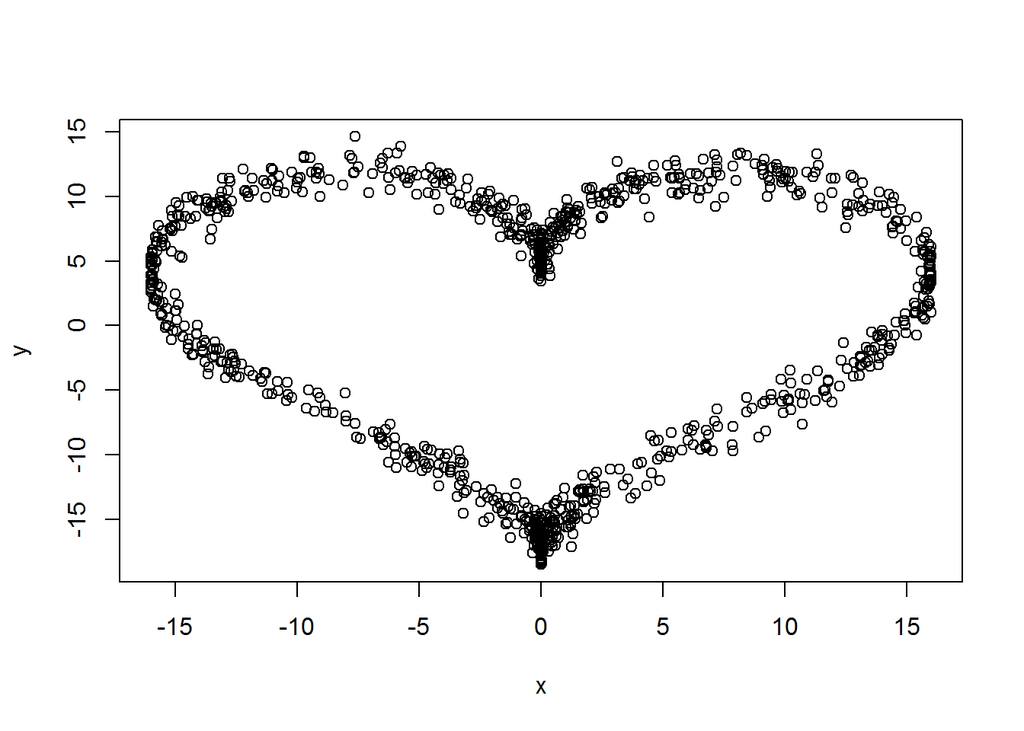

```r
plot(x,y)
```

### Multivariate Regression

**7. Test the linear association between HEARTRTE and BMI while adjusting for age effect on HEARTRTE.**

**Solution:**

```r
summary(HEARTRTE)
```

```
##    Min. 1st Qu.  Median    Mean 3rd Qu.    Max.    NA's
##   40.00   70.00   80.00   78.76   88.00  156.00       8
```

```r
summary(AGE)
```

```
##    Min. 1st Qu.  Median    Mean 3rd Qu.    Max.
##   21.00   57.00   65.00   63.48   71.00   94.00
```

```r
summary(BMI)
```

```
##    Min. 1st Qu.  Median    Mean 3rd Qu.    Max.    NA's
##   14.44   23.68   26.50   27.11   29.80   62.66       1
```

```r
fit <- lm(HEARTRTE ~ AGE+BMI)
summary(fit)
```

```
##
## Call:
## lm(formula = HEARTRTE ~ AGE + BMI)
##
## Residuals:
##     Min      1Q  Median      3Q     Max
## -39.208  -8.638   0.529   8.877  77.729
##
## Coefficients:
##             Estimate Std. Error t value Pr(>|t|)
## (Intercept) 75.44503    1.21070  62.315   <2e-16 ***
## AGE          0.02330    0.01406   1.657   0.0975 .
## BMI          0.06767    0.02957   2.289   0.0221 *
## ---
## Signif. codes:  0 '***' 0.001 '**' 0.01 '*' 0.05 '.' 0.1 ' ' 1
##
## Residual standard error: 12.65 on 6788 degrees of freedom
##   (9 observations deleted due to missingness)
## Multiple R-squared:  0.001172,   Adjusted R-squared:  0.000878
## F-statistic: 3.984 on 2 and 6788 DF,  p-value: 0.01866
```

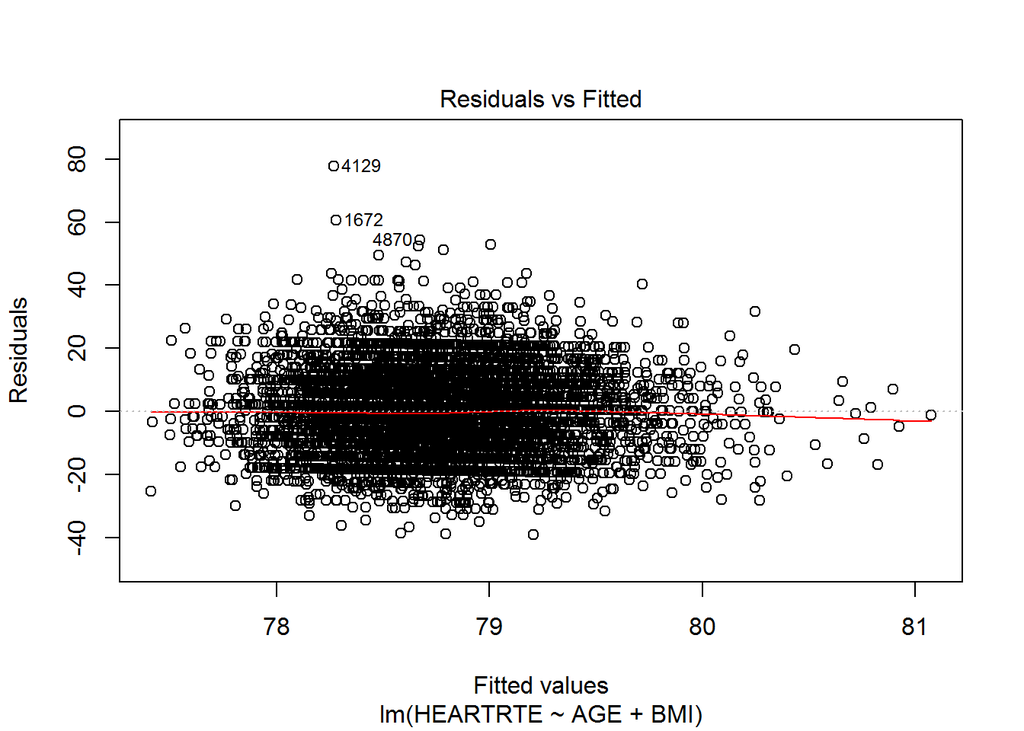

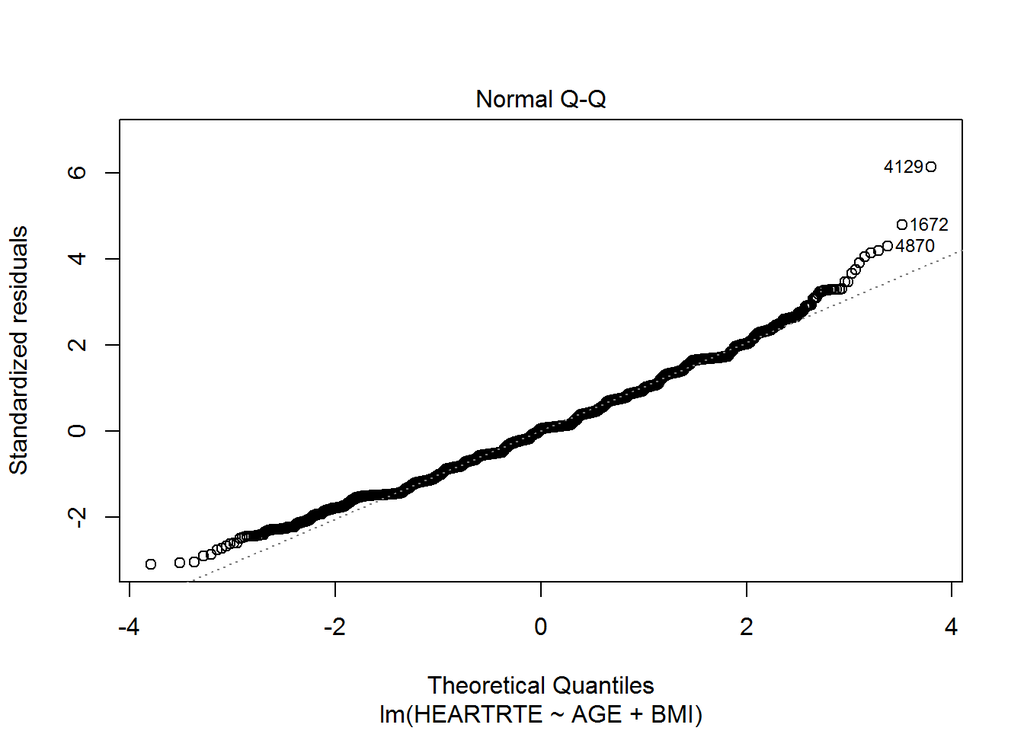

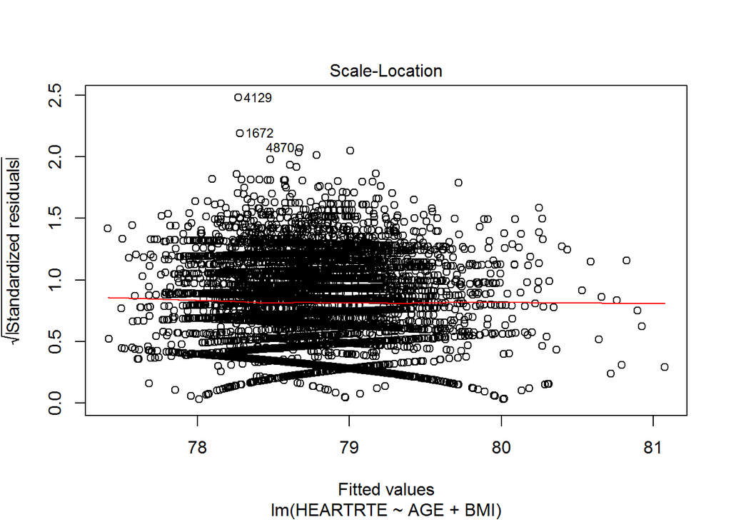

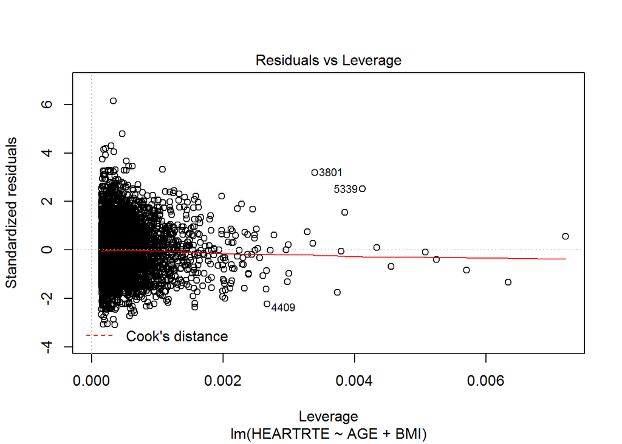

```r
## model diagnostics
plot(fit)
```

```r
car::ncvTest(fit)
```

```
## Non-constant Variance Score Test
## Variance formula: ~ fitted.values
## Chisquare = 2.526427    Df = 1     p = 0.1119534
```

```r
car::vif(fit)
```

```
##      AGE      BMI
## 1.000006 1.000006
```

```r
kappa(fit)^0.5
```

```
## [1] 19.85156
```

```r
cor.test(AGE, BMI)
```

```
##
##  Pearson's product-moment correlation
##
## data:  AGE and BMI
## t = -0.20944, df = 6797, p-value = 0.8341
## alternative hypothesis: true correlation is not equal to 0
## 95 percent confidence interval:
##  -0.02630931  0.02123153
## sample estimates:
##          cor
## -0.002540326
```

**8. Run the following simulation code first and then**

- **regress y on x**
- **generate the model diagnostic plots**
- **plot the histgram of x**

```r
set.seed(1234)
x <- rnbinom(1000, mu = 4, size = 1)
y <- 3+5*x+rnorm(1000)
```

**Solution:**

```r
fit <- lm(y~x)
summary(fit)
```

```
##
## Call:
## lm(formula = y ~ x)
##
## Residuals:
##     Min      1Q  Median      3Q     Max
## -2.9376 -0.7006  0.0364  0.6751  2.9808
##
## Coefficients:
##             Estimate Std. Error t value Pr(>|t|)
## (Intercept)  3.04168    0.04135   73.57   <2e-16 ***
## x            4.99839    0.00659  758.46   <2e-16 ***
## ---
## Signif. codes:  0 '***' 0.001 '**' 0.01 '*' 0.05 '.' 0.1 ' ' 1
##
## Residual standard error: 0.9862 on 998 degrees of freedom
## Multiple R-squared:  0.9983, Adjusted R-squared:  0.9983
## F-statistic: 5.753e+05 on 1 and 998 DF,  p-value: < 2.2e-16
```

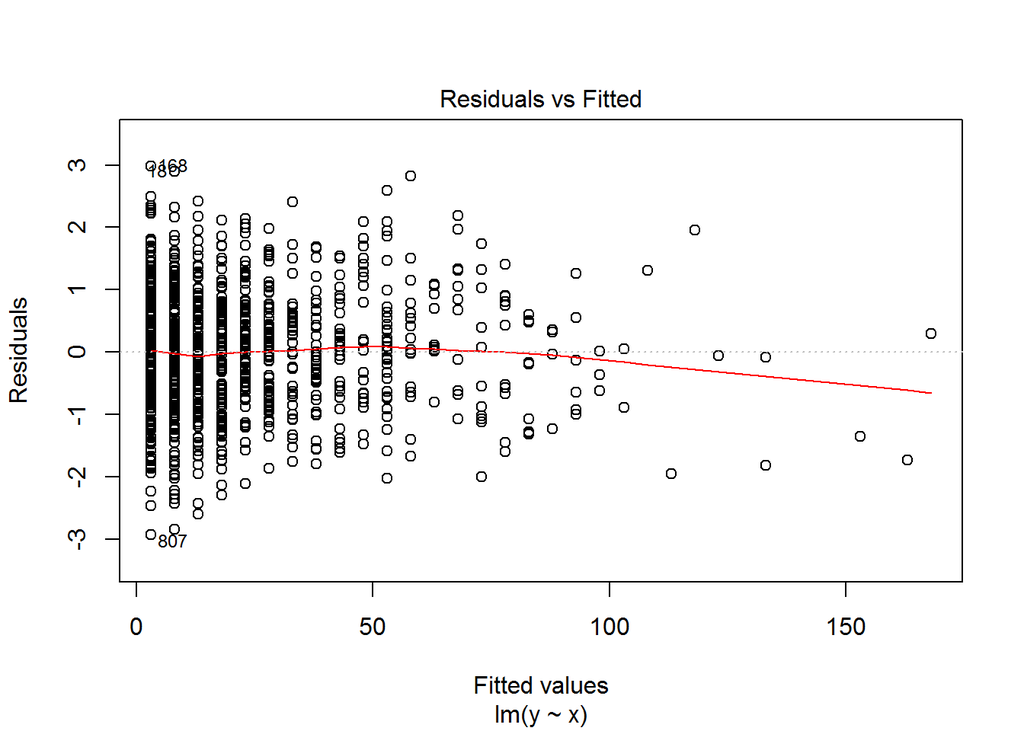

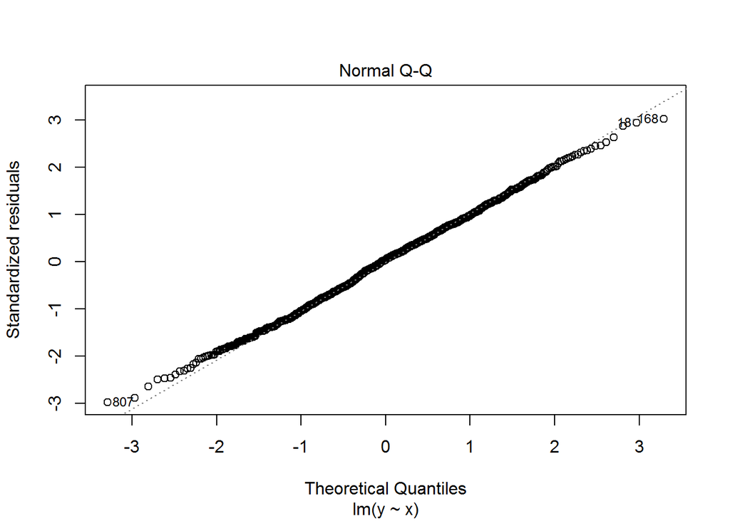

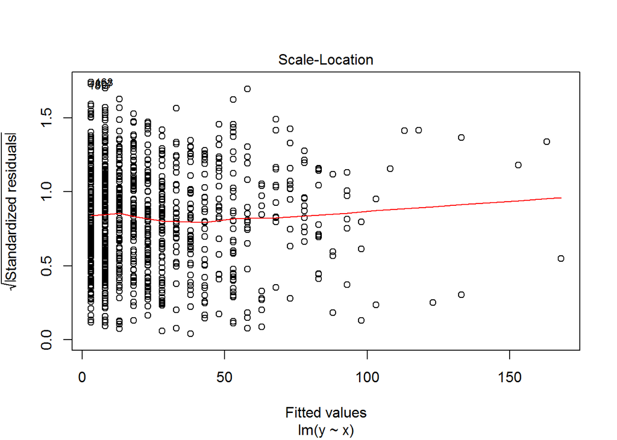

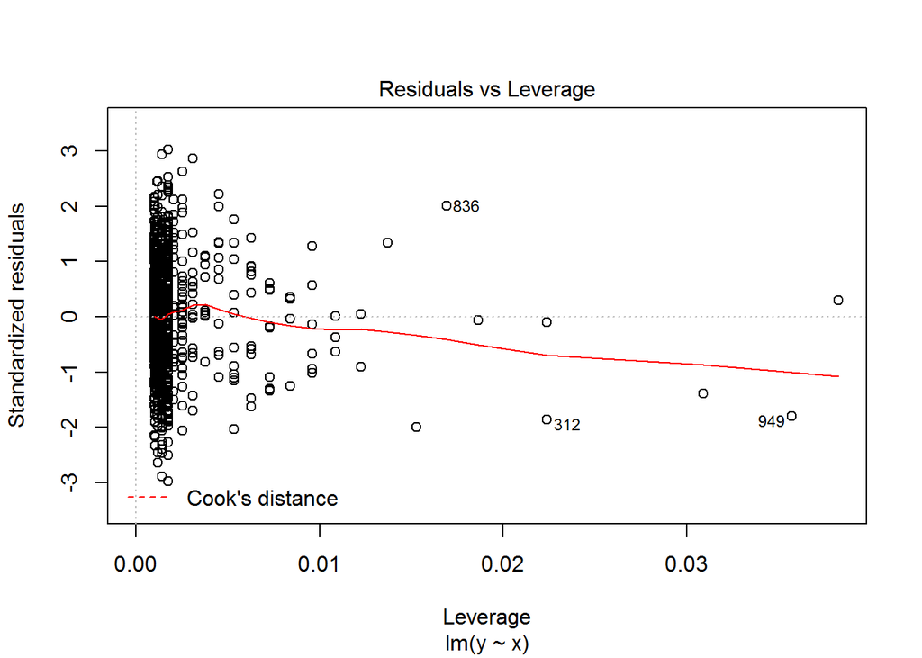

```r
plot(fit)
```

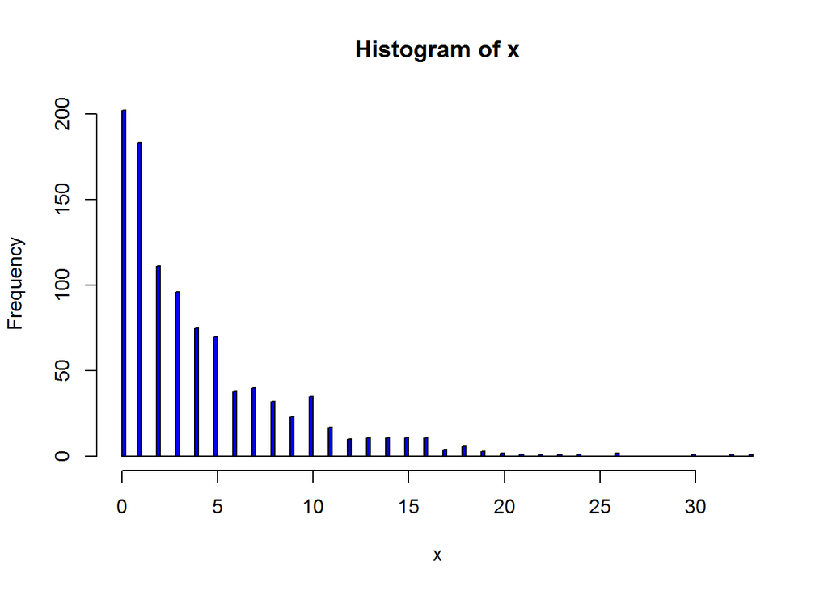

```r
hist(x, breaks=200, col="blue")
```

### Negative Binomial

**9. simulate a negative binomial sample with r=4, p=0.3, and sample size n=10,000, and then**

- **generate a histogram of the sample**
- **calculate sample mean and sample variance**
- **calculate theoretical mean and variance of the NB with r=4 and p=0.3**

**Solution:**

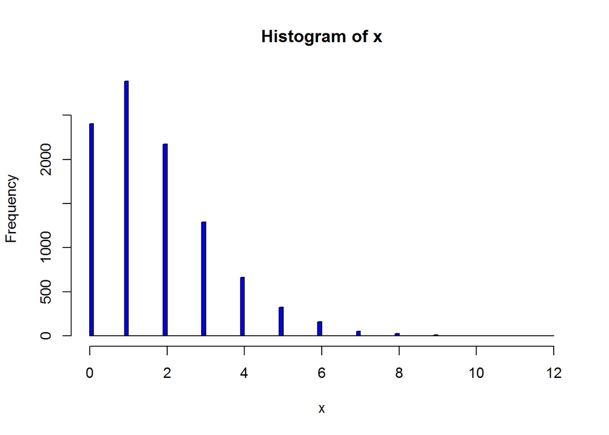

```
## mean(x):  1.7114
## var(x):  2.448555
## r*p/(1-p):  1.714286
## r*p/(1-p)^2:  2.44898
```

```r
nbsim <- function(r, p, n){
  x <- rnbinom(n, size = r, prob=(1-p))
  hist(x, breaks=100,col="blue")
  cat("mean(x): ", mean(x), "\n")
  cat("var(x): ", var(x), "\n")
  cat("r*p/(1-p): ", r*p/(1-p), "\n")
  cat("r*p/(1-p)^2: ", r*p/(1-p)^2, "\n")
}

nbsim(4, 0.3, 10000)
```

## Principal Component Analysis

**10. Run the following code to load the crab data and then perform PCA to condense the information contained in the continuous measurements.**

```r
data("crabs", package="MASS")
```

```r
? crabs  ## data description
```

**Solution:**

```r
cor(crabs[,4:8])
```

```
##           FL        RW        CL        CW        BD
## FL 1.0000000 0.9069876 0.9788418 0.9649558 0.9876272
## RW 0.9069876 1.0000000 0.8927430 0.9004021 0.8892054
## CL 0.9788418 0.8927430 1.0000000 0.9950225 0.9832038
## CW 0.9649558 0.9004021 0.9950225 1.0000000 0.9678117
## BD 0.9876272 0.8892054 0.9832038 0.9678117 1.0000000
```

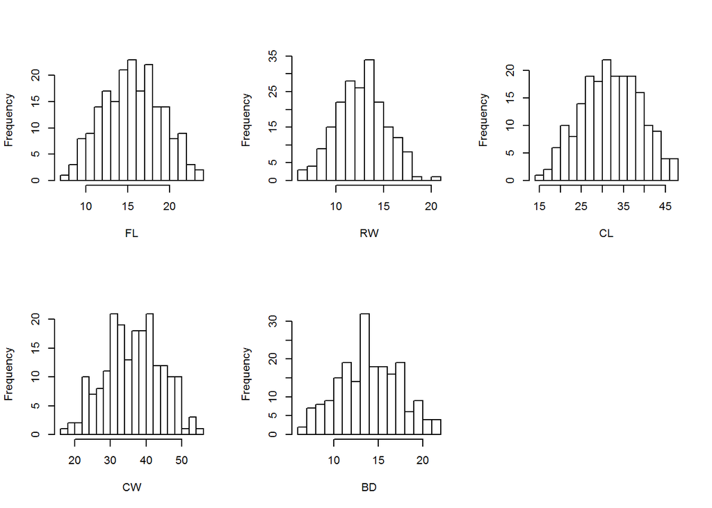

```r
par(mfrow=c(2,3))
tmp <- lapply(4:8,function(x){hist(crabs[,x],breaks=15, xlab=names(crabs)[x], main="")})
par(mfrow=c(1,1))
```

```r
apply(crabs[,4:8],2,summary)
```

```
##            FL    RW    CL    CW    BD
## Min.     7.20  6.50 14.70 17.10  6.10
## 1st Qu. 12.90 11.00 27.28 31.50 11.40
## Median  15.55 12.80 32.10 36.80 13.90
## Mean    15.58 12.74 32.11 36.41 14.03
## 3rd Qu. 18.05 14.30 37.22 42.00 16.60
## Max.    23.10 20.20 47.60 54.60 21.60
```

```r
crabs.pca <- prcomp(crabs[,4:8], center = TRUE, scale = TRUE)

print(crabs.pca)
```

```
## Standard deviations:
## [1] 2.18834065 0.38946785 0.21594669 0.10552420 0.04137243
##
## Rotation:
##          PC1        PC2         PC3          PC4         PC5
## FL 0.4520437  0.1375813  0.53076841  0.696923372  0.09649156
## RW 0.4280774 -0.8981307 -0.01197915 -0.083703203 -0.05441759
## CL 0.4531910  0.2682381 -0.30968155 -0.001444633 -0.79168267
## CW 0.4511127  0.1805959 -0.65256956  0.089187816  0.57452672
## BD 0.4511336  0.2643219  0.44316103 -0.706636423  0.17574331
```

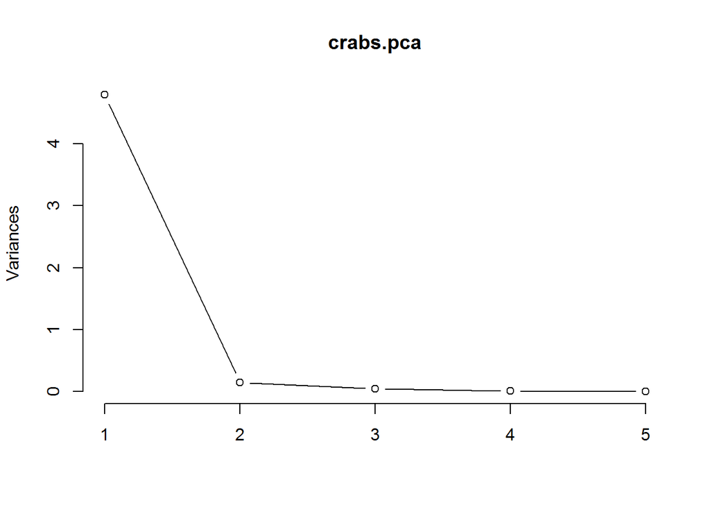

```r
plot(crabs.pca, type = "l");
```

```r
summary(crabs.pca)
```

```
## Importance of components:
##                           PC1     PC2     PC3     PC4     PC5
## Standard deviation     2.1883 0.38947 0.21595 0.10552 0.04137
## Proportion of Variance 0.9578 0.03034 0.00933 0.00223 0.00034
## Cumulative Proportion  0.9578 0.98810 0.99743 0.99966 1.00000
```

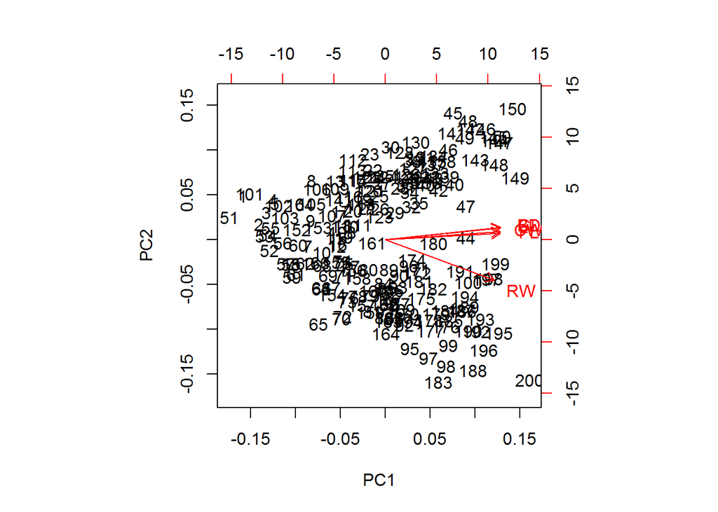

```r
biplot(crabs.pca)
```

**11. Without running the following simulation code, determine how many major principal components will be generated for this simulation data if PCA is performed.**

```r
set.seed(1234)
x1 <- runif(1000)
x2 <- 1+7*x1
x3 <- runif(1000)
x4 <- 2*x3
x5 <- runif(1000)
x6 <- runif(1000)
data <- cbind(x1, x2, x3, x4, x5, x6)
```

**Solution:** 4 major principal components.

```r
data.pca <- prcomp(data, center=T, scale=T)
print(data.pca)
```

```
## Standard deviations:
## [1] 1.433978e+00 1.396085e+00 1.006048e+00 9.912228e-01 1.530203e-15
## [6] 9.124773e-16
##
## Rotation:
##            PC1         PC2         PC3         PC4           PC5
## x1  0.49451238 -0.50465378  0.01302961 -0.02474449  1.000807e-02
## x2  0.49451238 -0.50465378  0.01302961 -0.02474449 -1.000807e-02
## x3  0.50475577  0.49325034  0.02071621  0.03868534  7.070360e-01
## x4  0.50475577  0.49325034  0.02071621  0.03868534 -7.070360e-01
## x5 -0.03375180 -0.05131013  0.68044058  0.73022510 -1.776736e-17
## x6  0.01480052 -0.03774369 -0.73198548  0.68011294 -2.537033e-17
##              PC6
## x1 -7.070360e-01
## x2  7.070360e-01
## x3  1.000807e-02
## x4 -1.000807e-02
## x5 -3.642919e-17
## x6  5.551115e-17
```

```r
summary(data.pca)
```

```
## Importance of components:
##                           PC1    PC2    PC3    PC4      PC5       PC6
## Standard deviation     1.4340 1.3961 1.0060 0.9912 1.53e-15 9.125e-16
## Proportion of Variance 0.3427 0.3248 0.1687 0.1638 0.00e+00 0.000e+00
## Cumulative Proportion  0.3427 0.6676 0.8363 1.0000 1.00e+00 1.000e+00
```

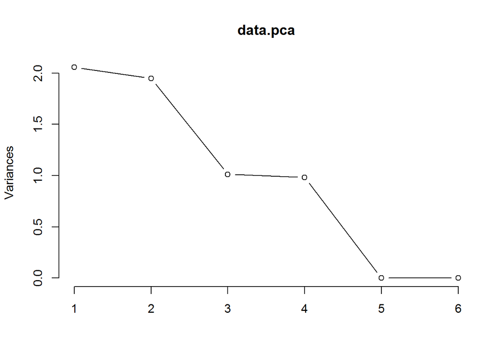

```r
plot(data.pca, type = "l")
```

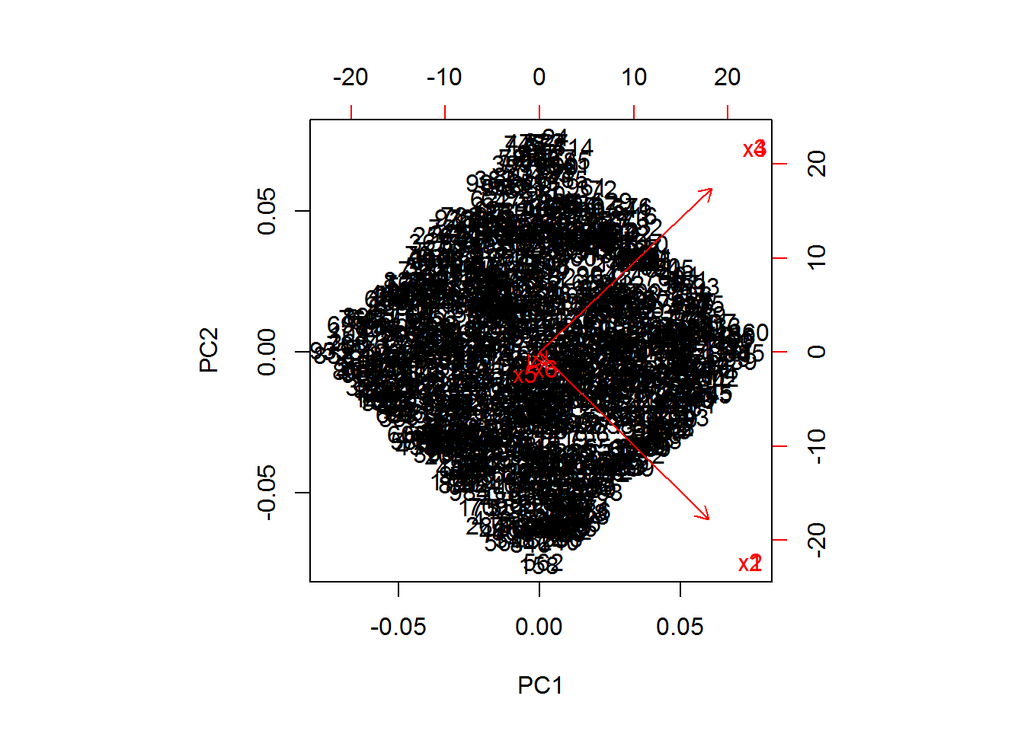

```r
biplot(data.pca)
```